# Lab 05 - Data Wrangling

# Learning goals

- Use the `merge()` function to join two datasets.
- Deal with missings and impute data.
- Identify relevant observations using `quantile()`.
- Practice your GitHub skills.

# Lab description

For this lab we will be dealing with the meteorological dataset `met`. In this case, we will use `data.table` to answer some questions regarding the `met` dataset, while at the same time practice your Git+GitHub skills for this project.

This markdown document should be rendered using `github_document` document.

# Part 1: Setup a Git project and the GitHub repository

1. Go to wherever you are planning to store the data on your computer, and create a folder for this project
2. In that folder, save [this template](https://github.com/JSC370/jsc370-2023/blob/main/labs/lab05/lab05-wrangling-gam.Rmd) as “README.Rmd”. This will be the markdown file where all the magic will happen.
3. Go to your GitHub account and create a new repository of the same name that your local folder has, e.g., “JSC370-labs”.
4. Initialize the Git project, add the “README.Rmd” file, and make your first commit.
5. Add the repo you just created on GitHub.com to the list of remotes, and push your commit to origin while setting the upstream.

Most of the steps can be done using command line:

```bash
# Step 1
cd ~/Documents
mkdir JSC370-labs
cd JSC370-labs

# Step 2
wget https://raw.githubusercontent.com/JSC370/jsc370-2023/main/labs/lab05/lab05-wrangling-gam.Rmd
mv lab05-wrangling-gam.Rmd README.Rmd
# if wget is not available,
curl https://raw.githubusercontent.com/JSC370/jsc370-2023/main/labs/lab05/lab05-wrangling-gam.Rmd --output README.Rmd

# Step 3
# Happens on github

# Step 4
git init
git add README.Rmd
git commit -m "First commit"

# Step 5
git remote add origin git@github.com:[username]/JSC370-labs
git push -u origin master
```

You can also complete the steps in R (replace with your paths/username when needed)

```r
# Step 1
setwd("~/Documents")
dir.create("JSC370-labs")
setwd("JSC370-labs")

# Step 2
download.file(
  "https://raw.githubusercontent.com/JSC370/jsc370-2023/main/labs/lab05/lab05-wrangling-gam.Rmd",
  destfile = "README.Rmd"
  )

# Step 3: Happens on Github

# Step 4
system("git init && git add README.Rmd")
system('git commit -m "First commit"')

# Step 5
system("git remote add origin git@github.com:[username]/JSC370-labs")
system("git push -u origin master")
```

Once you are done setting up the project, you can now start working with the MET data.

## Setup in R

1. Load the `data.table` (and the `dtplyr` and `dplyr` packages if you plan to work with those).

```r
library(data.table)
library(dtplyr)
library(dplyr)
```

2. Load the met data from https://github.com/JSC370/jsc370-2023/blob/main/labs/lab03/met_all.gz or (Use https://raw.githubusercontent.com/JSC370/jsc370-2023/main/labs/lab03/met_all.gz to download programmatically), and also the station data. For the latter, you can use the code we used during lecture to pre-process the stations data:

```r
met_url <- "https://raw.githubusercontent.com/JSC370/jsc370-2023/main/labs/lab03/met_all.gz"
# Downloading the data to a tempfile (so it is destroyed afterwards)
# you can replace this with, for example, your own data:
# tmp <- tempfile(fileext = ".gz")
tmp <- "met_all.gz"
# We sould be downloading this, ONLY IF this was not downloaded already.
# otherwise is just a waste of time.
if (!file.exists(tmp)) {
 download.file(
 url = met_url,
 destfile = tmp,
 method = "libcurl", timeout = 1000
 )
}
dat = fread(tmp)
```

```r
head(dat)
```

```
##    USAFID  WBAN year month day hour min  lat      lon elev wind.dir wind.dir.qc
## 1: 690150 93121 2019     8   1    0  56 34.3 -116.166  696      220           5
## 2: 690150 93121 2019     8   1    1  56 34.3 -116.166  696      230           5
## 3: 690150 93121 2019     8   1    2  56 34.3 -116.166  696      230           5
## 4: 690150 93121 2019     8   1    3  56 34.3 -116.166  696      210           5
## 5: 690150 93121 2019     8   1    4  56 34.3 -116.166  696      120           5
## 6: 690150 93121 2019     8   1    5  56 34.3 -116.166  696       NA           9
##    wind.type.code wind.sp wind.sp.qc ceiling.ht ceiling.ht.qc ceiling.ht.method
## 1:              N     5.7          5      22000             5                 9
## 2:              N     8.2          5      22000             5                 9
## 3:              N     6.7          5      22000             5                 9
## 4:              N     5.1          5      22000             5                 9
## 5:              N     2.1          5      22000             5                 9
## 6:              C     0.0          5      22000             5                 9
##    sky.cond vis.dist vis.dist.qc vis.var vis.var.qc temp temp.qc dew.point
## 1:        N    16093           5       N          5 37.2       5      10.6
## 2:        N    16093           5       N          5 35.6       5      10.6
## 3:        N    16093           5       N          5 34.4       5       7.2
## 4:        N    16093           5       N          5 33.3       5       5.0
## 5:        N    16093           5       N          5 32.8       5       5.0
## 6:        N    16093           5       N          5 31.1       5       5.6
##    dew.point.qc atm.press atm.press.qc       rh
## 1:            5    1009.9            5 19.88127
## 2:            5    1010.3            5 21.76098
## 3:            5    1010.6            5 18.48212
## 4:            5    1011.6            5 16.88862
## 5:            5    1012.7            5 17.38410
## 6:            5    1012.7            5 20.01540
```

```r
# Download the data
stations <- fread("ftp://ftp.ncdc.noaa.gov/pub/data/noaa/isd-history.csv")
stations[, USAF := as.integer(USAF)]
# Dealing with NAs and 999999
stations[, USAF   := fifelse(USAF == 999999, NA_integer_, USAF)]
stations[, CTRY   := fifelse(CTRY == "", NA_character_, CTRY)]
stations[, STATE  := fifelse(STATE == "", NA_character_, STATE)]

# Selecting the three relevant columns, and keeping unique records
stations <- unique(stations[, list(USAF, CTRY, STATE)])

# Dropping NAs
stations <- stations[!is.na(USAF)]

# Removing duplicates
stations[, n := 1:.N, by = .(USAF)]
stations <- stations[n == 1,][, n := NULL]
```

3. Merge the data as we did during the lecture.

```r
dat <- merge(
# Data
 x = dat,
 y = stations,
# List of variables to match
 by.x = "USAFID",
 by.y = "USAF",
# Which obs to keep?
 all.x = TRUE,
 all.y = FALSE
 )
```

```r
met_lz = lazy_dt(dat, immutable = FALSE)
```

```r
met_lz
```

```
## Source: local data table [2,377,343 x 32]
## Call:   `_DT1`
##
##   USAFID  WBAN  year month   day  hour   min   lat   lon  elev wind.dir wind.d…¹
##    <int> <int> <int> <int> <int> <int> <int> <dbl> <dbl> <int>    <int> <chr>
## 1 690150 93121  2019     8     1     0    56  34.3 -116.   696      220 5
## 2 690150 93121  2019     8     1     1    56  34.3 -116.   696      230 5
## 3 690150 93121  2019     8     1     2    56  34.3 -116.   696      230 5
## 4 690150 93121  2019     8     1     3    56  34.3 -116.   696      210 5
## 5 690150 93121  2019     8     1     4    56  34.3 -116.   696      120 5
## 6 690150 93121  2019     8     1     5    56  34.3 -116.   696       NA 9
## # … with 2,377,337 more rows, 20 more variables: wind.type.code <chr>,
## #   wind.sp <dbl>, wind.sp.qc <chr>, ceiling.ht <int>, ceiling.ht.qc <int>,
## #   ceiling.ht.method <chr>, sky.cond <chr>, vis.dist <int>, vis.dist.qc <chr>,
## #   vis.var <chr>, vis.var.qc <chr>, temp <dbl>, temp.qc <chr>,
## #   dew.point <dbl>, dew.point.qc <chr>, atm.press <dbl>, atm.press.qc <int>,
## #   rh <dbl>, CTRY <chr>, STATE <chr>, and abbreviated variable name
## #   ¹wind.dir.qc
##
## # Use as.data.table()/as.data.frame()/as_tibble() to access results
```

## Question 1: Representative station for the US

Across all weather stations, what is the median station in terms of temperature, wind speed, and atmospheric pressure? Look for the three weather stations that best represent continental US using the `quantile()` function. Do these three coincide?

```r
#avg for each station
met_avg = met_lz %>%
  group_by(USAFID) %>%
  summarise(
    across(
      c(temp, wind.sp, atm.press),
      function(x) mean(x, na.rm = TRUE)
    )
#    temp = mean(temp, na.rm = TRUE),
#    wind.sp = mean(wind.sp, na.rm = TRUE),
#    atm.press = mean(atm.press, na.rm = TRUE)
  )
```

```r
met_med = met_avg %>%
  summarise(across(
    2:4,
    function(x) quantile(x, probs = .5, na.rm = TRUE)
  ))
```

```r
met_med
```

```
## Source: local data table [1 x 3]
## Call:   `_DT1`[, .(temp = (function (x)
## mean(x, na.rm = TRUE))(temp), wind.sp = (function (x)
## mean(x, na.rm = TRUE))(wind.sp), atm.press = (function (x)
## mean(x, na.rm = TRUE))(atm.press)), keyby = .(USAFID)][, .(temp = (function (x)
## quantile(x, probs = 0.5, na.rm = TRUE))(temp), wind.sp = (function (x)
## quantile(x, probs = 0.5, na.rm = TRUE))(wind.sp), atm.press = (function (x)
## quantile(x, probs = 0.5, na.rm = TRUE))(atm.press))]
##
##    temp wind.sp atm.press
##   <dbl>   <dbl>     <dbl>
## 1  23.7    2.46     1015.
##
## # Use as.data.table()/as.data.frame()/as_tibble() to access results
```

```r
met_avg %>%
  filter(
    temp == met_med %>% pull(temp) |
    wind.sp == met_med %>% pull(wind.sp) |
    atm.press == met_med %>% pull(atm.press)
  )
```

```
## Source: local data table [1 x 4]
## Call:   `_DT1`[, .(temp = (function (x)
## mean(x, na.rm = TRUE))(temp), wind.sp = (function (x)
## mean(x, na.rm = TRUE))(wind.sp), atm.press = (function (x)
## mean(x, na.rm = TRUE))(atm.press)), keyby = .(USAFID)][temp ==
##     met_med %>% pull(temp) | wind.sp == met_med %>% pull(wind.sp) |
##     atm.press == met_med %>% pull(atm.press)]
##
##   USAFID  temp wind.sp atm.press
##    <int> <dbl>   <dbl>     <dbl>
## 1 720929  17.4    2.46       NaN
##
## # Use as.data.table()/as.data.frame()/as_tibble() to access results
```

```r
med_temp_id = met_avg %>%
  mutate(temp_diff = abs(temp - met_med %>% pull(temp))) %>%
  arrange(temp_diff) %>%
  slice(1)
med_windsp_id = met_avg %>%
  mutate(wind_diff = abs(wind.sp - met_med %>% pull(wind.sp))) %>%
  arrange(wind_diff) %>%
  slice(1)
med_atmp_id = met_avg %>%
  mutate(atmp_diff = abs(atm.press - met_med %>% pull(atm.press))) %>%
  arrange(atmp_diff) %>%
  slice(1)
```

```r
med_temp_id
```

```
## Source: local data table [1 x 5]
## Call:   `_DT1`[, .(temp = (function (x)
## mean(x, na.rm = TRUE))(temp), wind.sp = (function (x)
## mean(x, na.rm = TRUE))(wind.sp), atm.press = (function (x)
## mean(x, na.rm = TRUE))(atm.press)), keyby = .(USAFID)][, `:=`(temp_diff = abs(temp -
##     ..met_med %>% pull(temp)))][order(temp_diff)][1[between(1,
##     -.N, .N)]]
##
##   USAFID  temp wind.sp atm.press temp_diff
##    <int> <dbl>   <dbl>     <dbl>     <dbl>
## 1 725515  23.7    2.71       NaN   0.00233
##
## # Use as.data.table()/as.data.frame()/as_tibble() to access results
```

```r
med_windsp_id
```

```
## Source: local data table [1 x 5]
## Call:   `_DT1`[, .(temp = (function (x)
## mean(x, na.rm = TRUE))(temp), wind.sp = (function (x)
## mean(x, na.rm = TRUE))(wind.sp), atm.press = (function (x)
## mean(x, na.rm = TRUE))(atm.press)), keyby = .(USAFID)][, `:=`(wind_diff = abs(wind.sp -
##     ..met_med %>% pull(wind.sp)))][order(wind_diff)][1[between(1,
##     -.N, .N)]]
##
##   USAFID  temp wind.sp atm.press wind_diff
##    <int> <dbl>   <dbl>     <dbl>     <dbl>
## 1 720929  17.4    2.46       NaN         0
##
## # Use as.data.table()/as.data.frame()/as_tibble() to access results
```

```r
med_atmp_id
```

```
## Source: local data table [1 x 5]
## Call:   `_DT1`[, .(temp = (function (x)
## mean(x, na.rm = TRUE))(temp), wind.sp = (function (x)
## mean(x, na.rm = TRUE))(wind.sp), atm.press = (function (x)
## mean(x, na.rm = TRUE))(atm.press)), keyby = .(USAFID)][, `:=`(atmp_diff = abs(atm.press -
##     ..met_med %>% pull(atm.press)))][order(atmp_diff)][1[between(1,
##     -.N, .N)]]
##
##   USAFID  temp wind.sp atm.press atmp_diff
##    <int> <dbl>   <dbl>     <dbl>     <dbl>
## 1 723200  25.8    1.54     1015.  0.000538
##
## # Use as.data.table()/as.data.frame()/as_tibble() to access results
```

```r
distinct(met_lz %>%
  filter(
    USAFID  == 725515 |
    USAFID  == 720929 |
    USAFID  == 723200
  ), USAFID, lat, lon)
```

```
## Source: local data table [5 x 3]
## Call:   unique(`_DT1`[USAFID == 725515 | USAFID == 720929 | USAFID ==
##     723200, .(USAFID, lat, lon)])
##
##   USAFID   lat   lon
##    <int> <dbl> <dbl>
## 1 720929  45.5 -92.0
## 2 723200  34.4 -85.2
## 3 723200  34.3 -85.2
## 4 723200  34.4 -85.2
## 5 725515  40.3 -96.8
##
## # Use as.data.table()/as.data.frame()/as_tibble() to access results
```

Knit the document, commit your changes, and save it on GitHub. Don’t forget to add `README.md` to the tree, the first time you render it.

## Question 2: Representative station per state

Just like the previous question, you are asked to identify what is the most representative, the median, station per state. This time, instead of looking at one variable at a time, look at the euclidean distance. If multiple stations show in the median, select the one located at the lowest latitude.

```r
met_avg_2 = met_lz %>%
  group_by(USAFID) %>%
  summarise(
    STATE = STATE,
    lon = lon,
    lat = lat,
    across(
      c(temp, wind.sp, atm.press),
      function(x) mean(x, na.rm = TRUE)
    )
  )

state_med = met_avg_2 %>%
  group_by(STATE) %>%
  summarise(
    across(
      c(temp, wind.sp, atm.press),
      function(x) quantile(x, probs = .5, na.rm = TRUE)
    )
  )
# 1 station for 3 variables
```

```r
met_avg_state_med = merge(x=met_avg_2,y=state_med,by="STATE",all.x=TRUE)
```

```r
met_avg_state_med
```

[output not shown]

```r
met_avg_state_med = met_avg_state_med %>%
  mutate(ecl_diff = sqrt((temp.x - temp.y)^2 +(wind.sp.x - wind.sp.y)^2+ (atm.press.x - atm.press.y)^2))
na.omit(met_avg_state_med)
state_med_final
```

[output not shown]

[output not shown]

[output not shown]

```r
med_by_state = distinct(merge(x=state_med_final,y=met_avg_state_med,by=c("STATE", "ecl_diff") ,all.x=TRUE))
```

```r
med_by_state
```

```
##    STATE  ecl_diff USAFID      lon    lat   temp.x wind.sp.x atm.press.x
## 1     AL 0.1917347 722286  -87.616 33.212 26.35793  1.675828    1014.909
## 2     AR 0.4024542 723407  -90.646 35.831 25.86949  2.208652    1014.575
## 3     AR 0.4024542 723407  -90.646 35.832 25.86949  2.208652    1014.575
## 4     AZ 1.7210317 723740 -110.720 35.028 27.20925  3.677113    1011.656
## 5     AZ 1.7210317 723740 -110.733 35.017 27.20925  3.677113    1011.656
## 6     AZ 1.7210317 723740 -110.723 35.022 27.20925  3.677113    1011.656
## 7     AZ 1.7210317 723740 -110.721 35.028 27.20925  3.677113    1011.656
## 8     CA 0.1736276 722977 -117.866 33.680 22.28589  2.364013    1012.653
## 9     CA 0.1736276 722977 -117.868 33.676 22.28589  2.364013    1012.653
## 10    CO 0.9658559 724665 -103.666 39.275 20.75472  3.946234    1012.891
## 11    CO 0.9658559 724665 -103.666 39.273 20.75472  3.946234    1012.891
## 12    CT 0.3085369 725087  -72.651 41.736 22.57539  2.126514    1014.534
## 13    CT 0.3085369 725087  -72.649 41.737 22.57539  2.126514    1014.534
## 14    DE 0.0000000 724180  -75.606 39.674 24.56026  2.752929    1015.046
```

[output cut: 185 more lines]

Knit the doc and save it on GitHub.

## Question 3: In the middle?

For each state, identify what is the station that is closest to the mid-point of the state. Combining these with the stations you identified in the previous question, use `leaflet()` to visualize all ~100 points in the same figure, applying different colors for those identified in this question.

```r
state_mid_pt = met_avg_2 %>%
  group_by(STATE) %>%
  summarise(
    avg_lon = mean(lon),
    avg_lat = mean(lat)
  )
```

```r
cal_state_mid_pt = merge(x=met_avg_2,y=state_mid_pt,by="STATE",all.x=TRUE)
```

```r
cal_state_mid_pt = cal_state_mid_pt %>% mutate(mid_pt_dist = sqrt((lon-avg_lon)^2 + (lat-avg_lat)^2))
```

```r
mid_pt_min = cal_state_mid_pt %>%
  group_by(STATE) %>%
  summarise(mid_pt_dist
 = min(mid_pt_dist, na.rm = TRUE))
```

```r
mid_pt_min
```

```
## # A tibble: 48 × 2
##    STATE mid_pt_dist
##    <chr>       <dbl>
##  1 AL         0.441
##  2 AR         0.411
##  3 AZ         0.396
##  4 CA         0.410
##  5 CO         0.196
##  6 CT         0.114
##  7 DE         0.0284
##  8 FL         0.149
##  9 GA         0.270
## 10 IA         0.180
## # … with 38 more rows
```

```r
mid_pt_min_by_state = distinct(merge(x=mid_pt_min,y=cal_state_mid_pt,by=c("STATE", "mid_pt_dist") ,all.x=TRUE))
```

```r
mid_pt_min_by_state
```

```
##    STATE mid_pt_dist USAFID      lon    lat     temp   wind.sp atm.press
## 1     AL  0.44100224 722300  -86.783 33.177 26.61913 1.4962283  1014.860
## 2     AR  0.41051820 723429  -93.093 35.259 26.41317 1.2792990  1013.768
## 3     AZ  0.39610992 723745 -111.339 34.257 25.47964 1.9323676       NaN
## 4     CA  0.40988686 723890 -119.717 36.767 29.15926 3.3677047  1011.154
## 5     CO  0.19618481 726396 -105.516 39.050 12.93812 2.5374887       NaN
## 6     CT  0.11435489 725027  -72.828 41.510 21.87299 1.6481552  1014.760
## 7     DE  0.02835187 724088  -75.467 39.133 24.72840 3.0324747  1014.860
## 8     FL  0.14923889 722014  -82.454 28.474 26.78411 2.2798568  1015.526
## 9     GA  0.27031495 722175  -83.592 32.640 26.53220 1.8966816  1015.247
## 10    IA  0.17965421 725466  -93.566 41.691 21.79148 2.7225459       NaN
## 11    ID  0.93867109 725864 -116.101 44.890 18.78831 1.9405114  1014.374
## 12    IL  0.27004682 724397  -88.916 40.477 22.03413 3.4911565  1015.253
## 13    IN  0.19492582 720961  -86.375 40.711 20.94252 2.0536596       NaN
## 14    KS  0.27577228 724506  -97.861 38.066 24.63259 3.6742527  1012.323
```

[output cut: 83 more lines]

```r
library(leaflet)
leaflet() %>%
  addProviderTiles('OpenStreetMap') %>%
  addCircles(data = mid_pt_min_by_state,
             lat = ~lat, lng = ~lon,
             opacity = 1,
             fillOpacity = 1,
             radius = 500,
             color = "#55dd77") %>%
  addCircles(data = med_by_state,
             lat = ~lat, lng = ~lon,
             opacity = 1,
             fillOpacity = 1,
             radius = 500)
```

[interactive chart not shown]

```r
#  addMarkers(lat = ~lat, lng = ~lon,
#             label = ~paste0(round(rh,2), 'rh'),
#            data = top10) %>%
```

Knit the doc and save it on GitHub.

## Question 4: Means of means

Using the `quantile()` function, generate a summary table that shows the number of states included, average temperature, wind-speed, and atmospheric pressure by the variable “average temperature level,” which you’ll need to create.

Start by computing the states’ average temperature. Use that measurement to classify them according to the following criteria:

- low: temp < 20
- Mid: temp >= 20 and temp < 25
- High: temp >= 25

```r
met_avg_2 %>%
  group_by(STATE) %>%
  summarise(
    avg_temp = quantile(temp, 0.5,na.rm = TRUE),
    avg_ws = quantile(wind.sp, 0.5,na.rm = TRUE),
    avg_atm = quantile(atm.press, 0.5,na.rm = TRUE)
  ) %>%
  mutate(avg_temp_lvl = ifelse(avg_temp < 20, "low", ifelse(avg_temp < 25, "mid", "high")))
```

```
## Source: local data table [48 x 5]
## Call:   `_DT1`[, .(STATE = STATE, lon = lon, lat = lat, temp = (function (x)
## mean(x, na.rm = TRUE))(temp), wind.sp = (function (x)
## mean(x, na.rm = TRUE))(wind.sp), atm.press = (function (x)
## mean(x, na.rm = TRUE))(atm.press)), keyby = .(USAFID)][, .(avg_temp = quantile(temp,
##     0.5, na.rm = TRUE), avg_ws = quantile(wind.sp, 0.5, na.rm = TRUE),
##     avg_atm = quantile(atm.press, 0.5, na.rm = TRUE)), keyby = .(STATE)][,
##     `:=`(avg_temp_lvl = fifelse(avg_temp < 20, "low", fifelse(avg_temp <
##         25, "mid", "high")))]
##
##   STATE avg_temp avg_ws avg_atm avg_temp_lvl
##   <chr>    <dbl>  <dbl>   <dbl> <chr>
## 1 AL        26.2   1.54   1015. high
## 2 AR        26.1   1.86   1015. high
## 3 AZ        27.7   3.02   1010. high
## 4 CA        22.3   2.52   1013. mid
## 5 CO        20.8   3.09   1013. mid
## 6 CT        22.4   2.08   1015. mid
## # … with 42 more rows
##
## # Use as.data.table()/as.data.frame()/as_tibble() to access results
```

Once you are done with that, you can compute the following:

- Number of entries (records),
- Number of NA entries,
- Number of stations,
- Number of states included, and
- Mean temperature, wind-speed, and atmospheric pressure.

```r
met_avg_2
```

```
## Source: local data table [2,377,343 x 7]
## Call:   `_DT1`[, .(STATE = STATE, lon = lon, lat = lat, temp = (function (x)
## mean(x, na.rm = TRUE))(temp), wind.sp = (function (x)
## mean(x, na.rm = TRUE))(wind.sp), atm.press = (function (x)
## mean(x, na.rm = TRUE))(atm.press)), keyby = .(USAFID)]
##
##   USAFID STATE   lon   lat  temp wind.sp atm.press
##    <int> <chr> <dbl> <dbl> <dbl>   <dbl>     <dbl>
## 1 690150 CA    -116.  34.3  33.2    3.48     1010.
## 2 690150 CA    -116.  34.3  33.2    3.48     1010.
## 3 690150 CA    -116.  34.3  33.2    3.48     1010.
## 4 690150 CA    -116.  34.3  33.2    3.48     1010.
## 5 690150 CA    -116.  34.3  33.2    3.48     1010.
## 6 690150 CA    -116.  34.3  33.2    3.48     1010.
## # … with 2,377,337 more rows
##
## # Use as.data.table()/as.data.frame()/as_tibble() to access results
```

```r
met_avg_2 %>%
  group_by(STATE) %>%
  summarise(
    NA_entry = sum(is.na(temp)) + sum(is.na(wind.sp))  + sum(is.na(atm.press)),
    avg_temp = mean(temp, na.rm = TRUE),
    avg_ws = mean(wind.sp, na.rm = TRUE),
    avg_atm = mean(atm.press, na.rm = TRUE)
  ) %>%
  mutate(avg_temp_lvl = ifelse(avg_temp < 20, "low", ifelse(avg_temp < 25, "mid", "high")))
```

```
## Source: local data table [48 x 6]
## Call:   `_DT1`[, .(STATE = STATE, lon = lon, lat = lat, temp = (function (x)
## mean(x, na.rm = TRUE))(temp), wind.sp = (function (x)
## mean(x, na.rm = TRUE))(wind.sp), atm.press = (function (x)
## mean(x, na.rm = TRUE))(atm.press)), keyby = .(USAFID)][, .(NA_entry = sum(is.na(temp)) +
##     sum(is.na(wind.sp)) + sum(is.na(atm.press)), avg_temp = mean(temp,
##     na.rm = TRUE), avg_ws = mean(wind.sp, na.rm = TRUE), avg_atm = mean(atm.press,
##     na.rm = TRUE)), keyby = .(STATE)][, `:=`(avg_temp_lvl = fifelse(avg_temp <
##     20, "low", fifelse(avg_temp < 25, "mid", "high")))]
##
##   STATE NA_entry avg_temp avg_ws avg_atm avg_temp_lvl
##   <chr>    <int>    <dbl>  <dbl>   <dbl> <chr>
## 1 AL       20203     26.2   1.56   1016. high
## 2 AR        7332     26.3   1.78   1015. high
## 3 AZ       15563     28.8   2.99   1011. high
## 4 CA       39368     22.4   2.62   1013. mid
## 5 CO       55055     19.6   3.09   1014. low
## 6 CT        2198     22.3   2.20   1015. mid
## # … with 42 more rows
##
## # Use as.data.table()/as.data.frame()/as_tibble() to access results
```

All by the levels described before. Knit the document, commit your changes, and push them to GitHub.

## Question 5: Advanced Regression

Let’s practice running regression models with smooth functions on X. We need the `mgcv` package and `gam()` function to do this.

- using your data with the median values per station, examine the association between median temperature (y) and median wind speed (x). Create a scatterplot of the two variables using ggplot2. Add both a linear regression line and a smooth line.
- fit both a linear model and a spline model (use `gam()` with a cubic regression spline on wind speed). Summarize and plot the results from the models and interpret which model is the best fit and why.

```r
library('mgcv')
```

```r
library('ggplot2')
library(tidyverse)
met_median = met_lz %>%
  group_by(USAFID) %>%
  summarise(
    STATE = STATE,
    lon = lon,
    lat = lat,
    across(
      c(temp, wind.sp, atm.press),
      function(x) quantile(x, 0.5,na.rm = TRUE)
    )
  )
```

```r
df = as.data.frame(distinct(met_median))
```

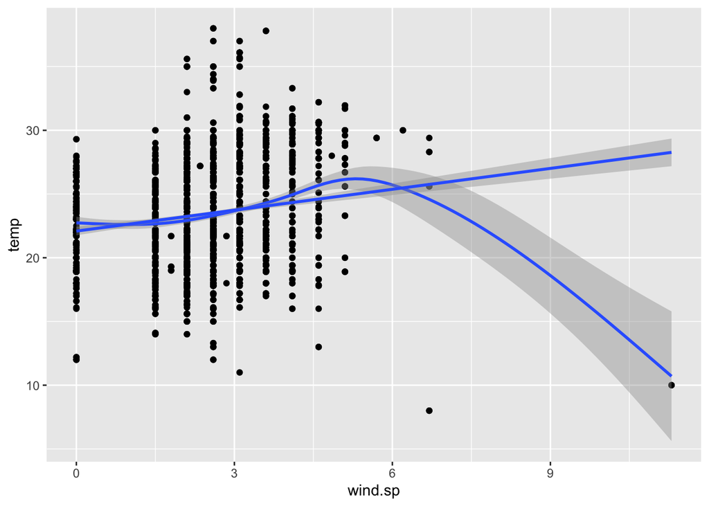

```r
df %>%
  ggplot(aes(x=wind.sp, y=temp)) +
  geom_point() +
  geom_smooth(method="auto") +
  geom_smooth(method="lm")
```

```r
model = lm(temp ~ wind.sp, data = met_median)
summary(model)
```

```
##
## Call:
## lm(formula = temp ~ wind.sp, data = met_median)
##
## Residuals:
##      Min       1Q   Median       3Q      Max
## -16.8815  -2.7007  -0.1948   2.8904  14.6978
##
## Coefficients:
##              Estimate Std. Error t value Pr(>|t|)
## (Intercept) 22.300683   0.005282    4222   <2e-16 ***
## wind.sp      0.385198   0.002071     186   <2e-16 ***
## ---
## Signif. codes:  0 '***' 0.001 '**' 0.01 '*' 0.05 '.' 0.1 ' ' 1
##
## Residual standard error: 3.837 on 2359319 degrees of freedom
##   (18022 observations deleted due to missingness)
## Multiple R-squared:  0.01445,    Adjusted R-squared:  0.01445
## F-statistic: 3.459e+04 on 1 and 2359319 DF,  p-value: < 2.2e-16
```

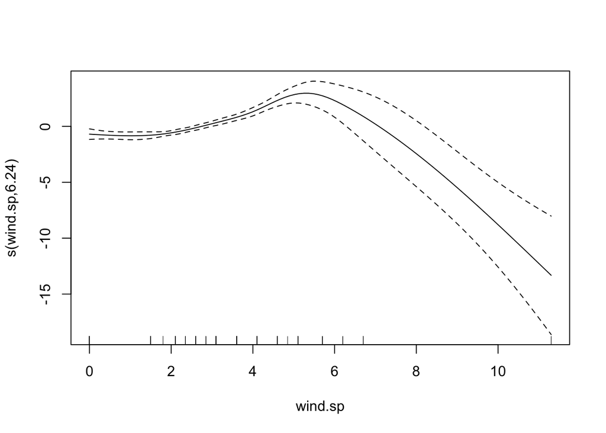

```r
gam_model = gam(temp ~ s(wind.sp, bs = "cr", k = 10), data = df)
plot(gam_model )
```

*The spline regression model fits the data better, because the the data doesn’t exactly shows a clear trend. The temperature increases and then decreases.*